# Activity Prediction

Vipin

4/27/2020

## Overview

Using devices such as Jawbone Up, Nike FuelBand, and Fitbit it is now possible to collect a large amount of data about personal activity relatively inexpensively. These type of devices are part of the quantified self movement – a group of enthusiasts who take measurements about themselves regularly to improve their health, to find patterns in their behavior, or because they are tech geeks. One thing that people regularly do is quantify how much of a particular activity they do, but they rarely quantify how well they do it. In this project, we will be to use data from accelerometers on the belt, forearm, arm, and dumbell of 6 participants.

For the purpose of this project, the following steps would be followed:

1. Data Preprocessing
2. Exploratory Analysis
3. Prediction Model Selection
4. Predicting Test Set Output

## Data Preprocessing

Loading data

```r
library(caret)
trainURL <- "http://d396qusza40orc.cloudfront.net/predmachlearn/pml-training.csv"
testURL <- "http://d396qusza40orc.cloudfront.net/predmachlearn/pml-testing.csv"
training <- read.csv(url(trainURL))
testing <- read.csv(url(testURL))
label <- createDataPartition(training$classe, p = 0.7, list = FALSE)
train <- training[label, ]
test <- training[-label, ]
dim(train)
```

```
## [1] 13737   160
```

Cleaning Data: Data contains 160 variable, out of which many have very less variance, some have lots of NA and some are only for identification.

```r
NZV <- nearZeroVar(train)
train <- train[ ,-NZV]
test <- test[ ,-NZV]
label <- apply(train, 2, function(x) mean(is.na(x))) > 0.95
train <- train[, -which(label, label == FALSE)]
test <- test[, -which(label, label == FALSE)]
train <- train[ , -(1:5)]
test <- test[ , -(1:5)]
dim(train)
```

```
## [1] 13737    54
```

So, now we are left with only 54 variables.

## Exploratory Analysis

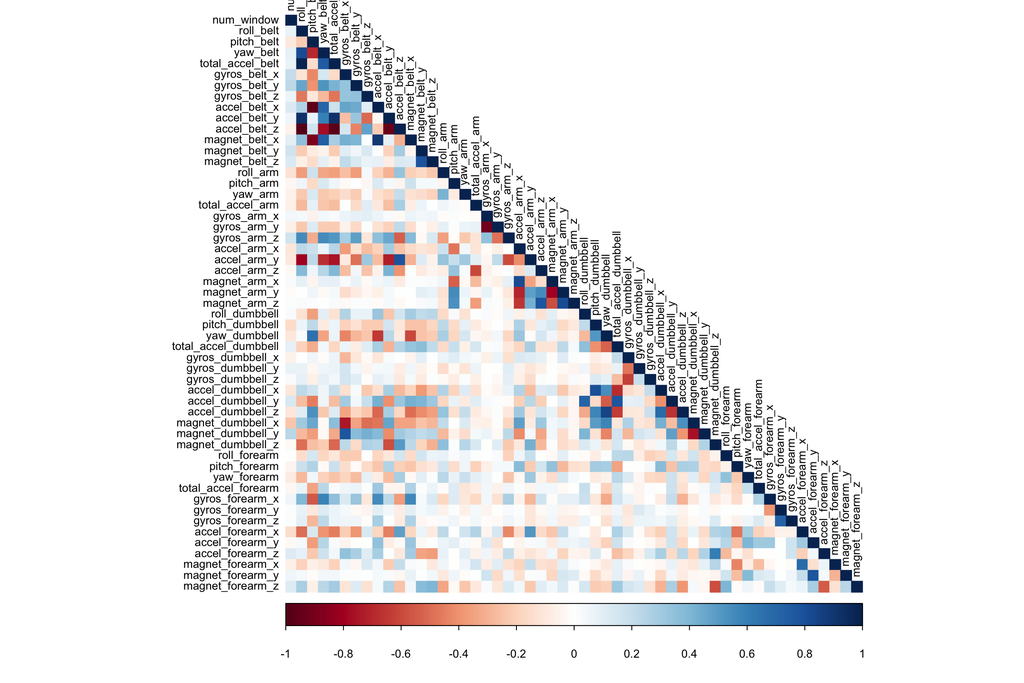

```r
library(corrplot)
corrMat <- cor(train[,-54])
corrplot(corrMat, method = "color", type = "lower", tl.cex = 0.8, tl.col = rgb(0,0,0))
```

So there are few correlations in the data. PCA can be use to further remove these correlations. But, as these correlations are very less, so we won’t be applying it.

## Prediction Model Selection

We will use 3 methods to model the training set and thereby choose the one having the best accuracy to predict the outcome variable in the testing set.  
The methods are 1. Decision Tree  
2. Random Forest  
3. Generalized Boosted Model

### Decision Tree

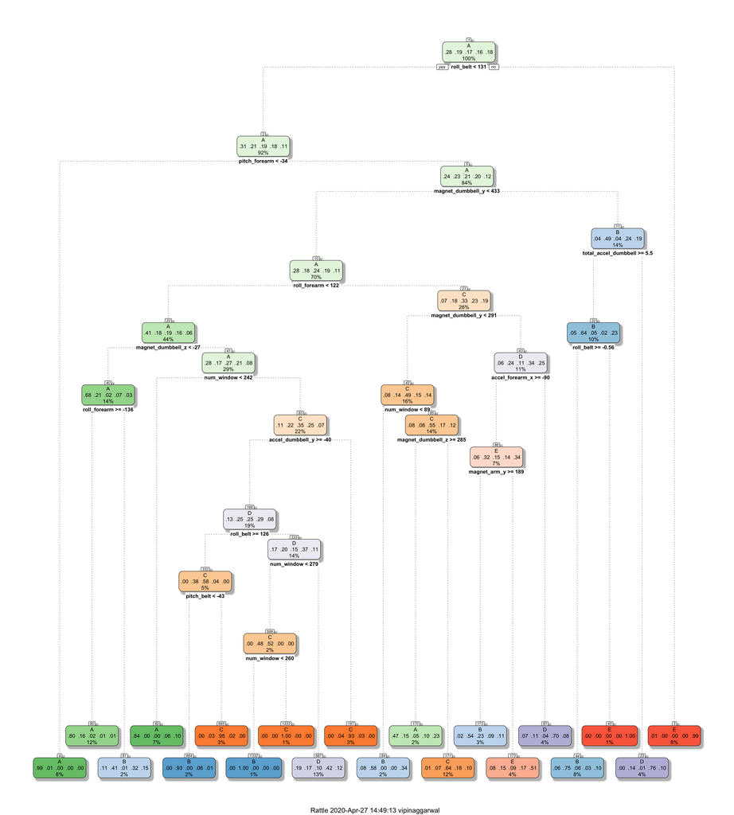

```r
library(rpart)
library(rpart.plot)
library(rattle)
set.seed(1590)
library(caret)
modelDT <- rpart(classe ~ ., data = train, method = "class")
fancyRpartPlot(modelDT)
```

```r
predictDT <- predict(modelDT, test, type = "class")
confMatDT <- confusionMatrix(predictDT, test$classe)
confMatDT
```

```
## Confusion Matrix and Statistics
##
##           Reference
## Prediction    A    B    C    D    E
##          A 1431  133   12   40   64
##          B   71  689   78   92  111
##          C   11   68  813  150   63
##          D  141  217   83  640  125
##          E   20   32   40   42  719
##
## Overall Statistics
##
##                Accuracy : 0.7293
##                  95% CI : (0.7178, 0.7406)
##     No Information Rate : 0.2845
##     P-Value [Acc > NIR] : < 2.2e-16
##
##                   Kappa : 0.6581
##
##  Mcnemar's Test P-Value : < 2.2e-16
##
## Statistics by Class:
##
##                      Class: A Class: B Class: C Class: D Class: E
## Sensitivity            0.8548   0.6049   0.7924   0.6639   0.6645
## Specificity            0.9409   0.9258   0.9399   0.8850   0.9721
## Pos Pred Value         0.8518   0.6619   0.7357   0.5307   0.8429
## Neg Pred Value         0.9422   0.9071   0.9554   0.9308   0.9279
## Prevalence             0.2845   0.1935   0.1743   0.1638   0.1839
## Detection Rate         0.2432   0.1171   0.1381   0.1088   0.1222
## Detection Prevalence   0.2855   0.1769   0.1878   0.2049   0.1449
## Balanced Accuracy      0.8979   0.7654   0.8662   0.7744   0.8183
```

### Random Forest

```r
library(caret)
set.seed(1590)
modelRF <- train(classe ~ ., data = train, method = "rf")
modelRF$finalModel
```

```
##
## Call:
##  randomForest(x = x, y = y, mtry = param$mtry)
##                Type of random forest: classification
##                      Number of trees: 500
## No. of variables tried at each split: 27
##
##         OOB estimate of  error rate: 0.25%
## Confusion matrix:
##      A    B    C    D    E  class.error
## A 3905    1    0    0    0 0.0002560164
## B   10 2645    3    0    0 0.0048908954
## C    0    4 2392    0    0 0.0016694491
## D    0    0    9 2242    1 0.0044404973
## E    0    0    0    6 2519 0.0023762376
```

```r
predictRF <- predict(modelRF, test)
confMatRF <- confusionMatrix(predictRF, test$classe)
confMatRF
```

```
## Confusion Matrix and Statistics
##
##           Reference
## Prediction    A    B    C    D    E
##          A 1673    4    0    0    0
##          B    0 1133    0    0    0
##          C    0    2 1026    4    0
##          D    0    0    0  960    0
##          E    1    0    0    0 1082
##
## Overall Statistics
##
##                Accuracy : 0.9981
##                  95% CI : (0.9967, 0.9991)
##     No Information Rate : 0.2845
##     P-Value [Acc > NIR] : < 2.2e-16
##
##                   Kappa : 0.9976
##
##  Mcnemar's Test P-Value : NA
##
## Statistics by Class:
##
##                      Class: A Class: B Class: C Class: D Class: E
## Sensitivity            0.9994   0.9947   1.0000   0.9959   1.0000
## Specificity            0.9991   1.0000   0.9988   1.0000   0.9998
## Pos Pred Value         0.9976   1.0000   0.9942   1.0000   0.9991
## Neg Pred Value         0.9998   0.9987   1.0000   0.9992   1.0000
## Prevalence             0.2845   0.1935   0.1743   0.1638   0.1839
## Detection Rate         0.2843   0.1925   0.1743   0.1631   0.1839
## Detection Prevalence   0.2850   0.1925   0.1754   0.1631   0.1840
## Balanced Accuracy      0.9992   0.9974   0.9994   0.9979   0.9999
```

### Generalized Boosted Model

```r
library(caret)
set.seed(1590)
modelGBM <- train(classe ~ ., data = train, method = "gbm", verbose = FALSE)
modelGBM$finalModel
```

```
## A gradient boosted model with multinomial loss function.
## 150 iterations were performed.
## There were 53 predictors of which 53 had non-zero influence.
```

```r
predictGBM <- predict(modelGBM, test)
confMatGBM <- confusionMatrix(predictGBM, test$classe)
confMatGBM
```

```
## Confusion Matrix and Statistics
##
##           Reference
## Prediction    A    B    C    D    E
##          A 1668   13    0    1    0
##          B    6 1115   11    4    4
##          C    0   11 1014   11    0
##          D    0    0    1  948    9
##          E    0    0    0    0 1069
##
## Overall Statistics
##
##                Accuracy : 0.9879
##                  95% CI : (0.9848, 0.9906)
##     No Information Rate : 0.2845
##     P-Value [Acc > NIR] : < 2.2e-16
##
##                   Kappa : 0.9847
##
##  Mcnemar's Test P-Value : NA
##
## Statistics by Class:
##
##                      Class: A Class: B Class: C Class: D Class: E
## Sensitivity            0.9964   0.9789   0.9883   0.9834   0.9880
## Specificity            0.9967   0.9947   0.9955   0.9980   1.0000
## Pos Pred Value         0.9917   0.9781   0.9788   0.9896   1.0000
## Neg Pred Value         0.9986   0.9949   0.9975   0.9968   0.9973
## Prevalence             0.2845   0.1935   0.1743   0.1638   0.1839
## Detection Rate         0.2834   0.1895   0.1723   0.1611   0.1816
## Detection Prevalence   0.2858   0.1937   0.1760   0.1628   0.1816
## Balanced Accuracy      0.9965   0.9868   0.9919   0.9907   0.9940
```

As Random Forest offers the maximum accuracy, we will go with Random Forest Model to predict our test data class variable.

## Predicting Test Set Output

```r
predictRF <- predict(modelRF, testing)
predictRF
```

```
##  [1] B A B A A E D B A A B C B A E E A B B B
## Levels: A B C D E
```